# A Crash Course in R

[Home](https://brendanjodowd.github.io)

## Introduction

### About R and RStudio

R is a flexible, convenient and powerful tool for managing and analysing data, and well as for creating publication materials such as visualisations, reports and dashboards. RStudio is an IDE (Integrated Development Environment) for using R. R is free to install, as is the open source edition of RStudio (there are professional and hosted versions of RStudio which are not free). In my opinion, R and RStudio provide at least as much of the functionality you would see in other quite expensive statistical computing platforms.

### About this guide

This guide will be just enough to get you going. It does not show the full range of features for every function. It uses tidyverse and isn’t very concerned with technical stuff going on under the hood.

### Getting help

The help function in R provides great documentation and examples for all functions. Use it by running `?` followed by the name of the function. For example, to find out more about the function `select` just run `?select`.

There are very good [cheatsheets for different packages on the RStudio website](https://www.rstudio.com/resources/cheatsheets/). One cheatsheet that you won’t find on that page but which I think is really useful for beginners is [the one on data wrangling](https://www.rstudio.com/wp-content/uploads/2015/02/data-wrangling-cheatsheet.pdf) (although some of the functions on that are out of date).

Finally there are a couple of good online forums where users post their coding problems and other users try to provide solutions. One of the most active of these is Stack Overflow. Try searching or posting your problem there if you are getting stuck. Users are more likely to be able to help if you provide a reproducible example, so try to provide enough code so that they can recreate the problem themselves.

### A word on web restrictions

R needs to access the web in order to download packages from CRAN. You may also want to import data from the web, e.g. through the csodata package for importing data from the CSO website. If you are having trouble with these steps then it may be because your organisation has not allowed R to access the web, so you might need to contact your IT department. If you are in the same organisation as me and you are experiencing difficulties, let me know, there are some settings that I can pass on that will help.

## Packages and Tidyverse

### About packages

The capabilities of R are extended through a wide array of packages. As a beginner with R, it is likely that all of the extra packages that you use will be downloaded from an online repository of packages called CRAN, which stands for the Comprehensive R Archive Network. Packages are downloaded from CRAN within the R environment, you rarely have to visit the CRAN website at all. There is a stringent process to getting your package included on CRAN which includes a series of checks and testing, so there is a very low likelihood of you ever downloading malicious code from CRAN.

### Tidyverse and Base R

Tidyverse is a very widely used collection of packages which makes it easier to write and read code in R. It is so commonly used that it is almost ubiquitous, so I wouldn’t hesitate to recommend that you begin learning R through tidyverse. If you are not using tidyverse and you are only using the handful of default packages in R then you would say that you are using ‘base R’, where ‘base’ is the main default package (I think there are seven default packages). This is not an ‘either-or’ decision, when you load tidyverse it is perfectly fine to write code using the ‘base’ set of functions. It’s good to understand base R, but I think it’s ok to pick this up as you go along rather than starting out with exclusive use of base R.

### Installing and loading

To install a package you use the function `install.packages`, so to install the tidyverse packages you run `install.packages("tidyverse")`. Then to use the package you have to load it into your environment using the function `library`, so to use the tidyverse functions and features you run `library(tidyverse)` (note you need inverted commas for `install.packages` but not for `library`). **You only have to install a package once, or again if you want to update the package, but you have to load the package every time you start a new session in R**. Note that the default packages that come with R do not have to be installed or loaded using `install.packages` and `library`.

### Core tidyverse and other tidyverse

Within tidyverse there are eight core packages, and then a couple of extra tidyverse packages. All of these are installed when you run `install.packages("tidyverse")`, but only the core packages are loaded when you run `library(tidyverse)` (plus a couple of back-end ones that you don’t really see). This is not something that you have to worry too much about, it just means that you have to run an extra `library` line when you want to use one of those extra tidyverse packages that are beyond the core ones. Extra tidyverse packages that I would often use include scales for formatting axes, lubridate for handling dates and times, and readxl for reading and writing Excel files. Some packages I like which aren’t from tidyverse (and require separate installation) include sf for maps, tictoc for timing how long it takes code to run, beepr for making ‘ding’ noises after code has finished running, and knitr for making html documents like this one.

**Click for a summary on types of packages**

A diagram which summarises the different types of package is shown below. The five main types (A, B, C, D and E) are described below. As a beginner you will probably only encounter types A and B.

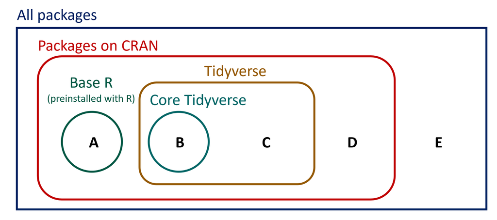

Diagram summarising types of packages

1. Base R: These packages are already installed with R and always loaded by default, so you don’t need to use `install.packages` or `library`. Examples include base which has lots of fundamental functions and stats which has functions for statistical analysis.
2. Core Tidyverse: These are the main tidyverse packages. They are all installed using `install.packages("tidyverse")` and loaded using `library(tidyverse)`. Examples include dplyr for data manipulation and stringr for manipulating strings.
3. Other Tidyverse: These are part of tidyverse but not among the core packages. They are also all installed using `install.packages("tidyverse")` but they are **not** loaded with `library(tidyverse)`, you have to use a separate `library` line to load these. Examples include lubridate for managing dates and times and haven for reading more unusual file types. You might use these kinds of packages as an intermediate user but not so much as a beginner.
4. Other packages on CRAN: There are over 18,000 packages on CRAN made by developers and organisations all over the world. These can be downloaded using `install.packages` and loaded using `library`. Examples include csodata for downloading CSO data, and caret for machine learning. As a beginner you will not encounter many of these.
5. Other packages not on CRAN: Many people make packages which for one reason or another are not on CRAN. For example a company may make a package for internal use only, or an individual might store several functions that they made themselves as a package on their own device (or maybe on GitHub) so that they can be easily added to their projects. These would be installed using a special configuration of `install.packages` or some other function, but once installed they can be loaded using `library`.

## The RStudio environment

A screenshot of RStudio is shown below. There are four main panels. This guide will not go through every single feature in RStudio, but will hopefully be enough to get you started.

[figure not shown]

A screenshot of the RStudio environment

## Data objects in R

### Vectors

Vectors are one-dimensional objects containing the same type of data, so all entries are either numerical, character (strings) or logical (TRUE or FALSE). These are created using the function `c()`, with the elements separated by commas. A vector of three names would look like: `c("Andy", "Betty" , "Carol")`. A vector of three numbers would look like: `c(71, 8.5 , 0.13)`. You can make a vector of consecutive integers by putting a colon (`:`) between the low and high integer, so `5:8` is equivalent to `c(5, 6, 7, 8)`. Finally, you can make a logical vector like so: `c(TRUE, FALSE, FALSE)`.

### Dataframes

Most of the data objects you’ll encounter will be **dataframes**, which can be thought of as tables with rows and columns. Each column has a particular type which can be numerical, character (strings) or logical (TRUE or FALSE). The columns of dataframes have names. The rows of dataframes can have names too, but this is a stupid feature, it makes more sense to just use another column for whatever information is stored as the row name.

**The columns of dataframes are vectors. So what?**

It is useful to know that the columns of dataframes are themselves vectors. Why is that useful to know? Two reasons. One is that you can extract a column from a dataframe and manipulate it as a vector. The second reason is that programming in R is generally geared towards working with vectors as the basic unit. It is easier to program in R with “long” datasets, where you have data for different groups stacked vertically, so you might have a column for X, a column for Y, and a column for group. If you were working in Excel you would probably arrange things differently, maybe with a “wide” dataset, having a column for X, then a column for Y_1 (representing group 1), a column for Y_2 (representing group 2), and so on. You will find that row-wise operations in R are not as straightforward as column-wise operations. Writing for loops over a dataframe is pretty slow and discouraged. You might notice other effects like this as you become more proficient.

In tidyverse, there is an improved version of a dataframe called a tibble. The differences between a tibble and a regular dataframe are quite subtle from the beginner’s perspective and they can more-or-less be handled in the same way, so I wouldn’t worry about it for now. Just be aware that if you see a reference to a ‘tibble’ then it’s a special type of a dataframe.

### Other structures

There are other objects in R including matrices, arrays and lists. You can skip this section if you like as it is unlikely you will need to deal with them as a beginner.

**Click for info on other structures**

A matrix is a 2D table with only one type of data (usually all numeric). An array is more general than a matrix, it can have any number of dimensions. I don’t think I have ever had to use matrices or arrays.

A list is a 1D structure where the elements don’t have to be of the same type, i.e. the first element could be a number and the second element could be a string. But moreover, the elements of lists can be vectors, dataframes, or even more lists. Dealing with lists would be for an intermediate or advanced course, but even as a beginner you might find yourself working with a package which uses lists. Often in these cases, the lists have a specific structure, or ‘class’, which is recognised by the package. Don’t panic, there will usually be a helpful vignette for you to follow.

## Fundamentals: Running Code and Creating Objects

This section covers just a couple of fundamental tools from Base R. . I prefer to do all my data filtering, manipulation and aggregation using tidyverse functions, so those kinds of processes are not covered here.

### How do I run code?

After you write some code in the scripting window you will want to run it. My preferred way to run code is to place the cursor somewhere in the line of code and press ‘Ctrl Enter’. As well as running the line of code, the cursor will then jump to the next line of code, and this is useful as it helps you to run several concurrent lines of code by holding ‘Ctrl’ and tapping ‘Enter’.

You can also write code directly in the console. After you write your code there, simply hit ‘Enter’ and it will run.

**Click to see other ways of running code**

There are other ways of running code from your scripting window. Pressing the ‘Run’ button at the top of the scripting window has the same effect as hitting ‘Ctrl Enter’. Instead of placing the cursor in the line of code you can select the whole line of code. You can select several lines of code and then hit ‘Ctrl Enter’ or ‘Run’, and they will all run in the order they appear.

Finally, you can run all of the code in the script by pressing ‘Ctrl Alt r’. Note that this also saves the script.

### The assignment operator `<-`

To create objects, we use the assignment operator: `<-` You can quickly write this operator by hitting ‘Alt -’. Let’s make an object `x` which has a value of 5.

```r
x <- 5
```

After you run this line of code you will see the code appear in the Console, and `x` appear in the Environment panel along with its value, 5.

To output the value of `x`, we can write `x` in a line on its own and run that line. The value 5 will appear in the Console. We can also run `x + 2` to return `7`.

```r
x
## [1] 5

x + 2
## [1] 7
```

Let’s make a vector containing a couple of numeric values using the function `c`, and output it as well.

```r
numbers_vec <- c(5,6,7,8,9)

numbers_vec
```

```
## [1] 5 6 7 8 9
```

**Click to see example of string and logical vectors**

We can make a vector of strings by putting each string in inverted commas. We can use single or double inverted commas.

```r
names_vec <- c("Mary", "Louise", "Tom")

names_vec
```

```
## [1] "Mary"   "Louise" "Tom"
```

And we can make a logical vector like so. Note that I am writing `T` and `F` which are abbreviations of `TRUE` and `FALSE` and work in exactly the same way.

```r
logical_vec <- c(T, F, F, T)

logical_vec
```

```
## [1]  TRUE FALSE FALSE  TRUE
```

I find that I very rarely need to make dataframes from scratch. As a beginner you usually work with built-in sample dataframes, and as a regular user you usually work with dataframes created from data from files or from the web.

Although the built-in datasets don’t appear in the Environment panel, they are all there waiting to be used. We will make our own copy of a dataset from a study on oesophageal cancer which is called `esoph`. Our copy of this dataset will be called `cancer`. Note that `cancer` will appear in the Environment panel.

```r
cancer <- esoph
```

| agegp | alcgp | tobgp | ncases | ncontrols |
| --- | --- | --- | --- | --- |
| 25-34 | 0-39g/day | 0-9g/day | 0 | 40 |
| 25-34 | 0-39g/day | 10-19 | 0 | 10 |
| 25-34 | 0-39g/day | 20-29 | 0 | 6 |
| 25-34 | 0-39g/day | 30+ | 0 | 5 |
| 25-34 | 40-79 | 0-9g/day | 0 | 27 |
| 25-34 | 40-79 | 10-19 | 0 | 7 |
| 25-34 | 40-79 | 20-29 | 0 | 4 |
| 25-34 | 40-79 | 30+ | 0 | 7 |
| 25-34 | 80-119 | 0-9g/day | 0 | 2 |
| 25-34 | 80-119 | 10-19 | 0 | 1 |
| 25-34 | 80-119 | 30+ | 0 | 2 |
| 25-34 | 120+ | 0-9g/day | 0 | 1 |
| 25-34 | 120+ | 10-19 | 1 | 0 |
| 25-34 | 120+ | 20-29 | 0 | 1 |
| 25-34 | 120+ | 30+ | 0 | 2 |
| 35-44 | 0-39g/day | 0-9g/day | 0 | 60 |
| 35-44 | 0-39g/day | 10-19 | 1 | 13 |
| 35-44 | 0-39g/day | 20-29 | 0 | 7 |
| 35-44 | 0-39g/day | 30+ | 0 | 8 |
| 35-44 | 40-79 | 0-9g/day | 0 | 35 |
| 35-44 | 40-79 | 10-19 | 3 | 20 |
| 35-44 | 40-79 | 20-29 | 1 | 13 |
| 35-44 | 40-79 | 30+ | 0 | 8 |
| 35-44 | 80-119 | 0-9g/day | 0 | 11 |
| 35-44 | 80-119 | 10-19 | 0 | 6 |
| 35-44 | 80-119 | 20-29 | 0 | 2 |
| 35-44 | 80-119 | 30+ | 0 | 1 |
| 35-44 | 120+ | 0-9g/day | 2 | 1 |
| 35-44 | 120+ | 10-19 | 0 | 3 |
| 35-44 | 120+ | 20-29 | 2 | 2 |

[output cut: 58 more lines]

**Click to see how to make a dataframe from scratch**

Like I say, this is something you rarely need to do. Dataframes are created using a bunch of named vectors separated by commas, within the function `data.frame()`. Here I am making a character variable called `name`, a numerical variable called `age`, and a logical variable called `married`.

```r
some_dataframe <- data.frame(name = c("Mary", "Louise", "Tom"),
                             age = c(30, 40, 50),
                             married = c(FALSE, TRUE, TRUE))
```

### Accessing elements with `[]` and `$`

We can use the square brackets `[]` to access specific elements within vectors and dataframes. Let’s create the vector `numbers_vec` as before and access the second element using `numbers_vec[2]`.

```r
numbers_vec <- c(5,6,7,8,9)
numbers_vec[2]
```

```
## [1] 6
```

Similarly we can access the i<sup>th</sup> row and the j<sup>th</sup> column of a dataframe using `[i,j]`. Let’s go to the fifth row of the second column of the `cancer` dataframe using `cancer[5,2]`.

```r
cancer <- esoph

cancer[5,2]
```

```
## [1] 40-79
## Levels: 0-39g/day < 40-79 < 80-119 < 120+
```

You’ll see in the output above that as well as giving the contents of that cell (which is `40-79`), it shows: `Levels: 0-39g/day < 40-79 < 80-119 < 120+`. This is because this particular variable (`alcgp`) is stored as a **factor**. A full discussion of factors would be better placed in an intermediate guide to R, but in this context a factor is a variable where each element can have one of several possible values or **levels**. The allowed levels of the variable `alcgp` are `0-39g/day`, `40-79`, `80-119` and `120+`. The levels of a factor can be given an order, in which case we would say that the variable is an ‘ordinal variable’. Factors have many uses. In particular they can be used for sorting string variables in an order that is not alphabetical, for example `Low`, `Medium`, `High`.

We can access a whole row or a whole column of a dataframe by using square brackets with either `i` or `j` left blank. For example, we can access the whole fifth row of `cancer` using `cancer[5,]`:

```r
cancer[5,]
```

```
##   agegp alcgp    tobgp ncases ncontrols
## 5 25-34 40-79 0-9g/day      0        27
```

To access a whole column we can leave `i` blank and include the value for `j` (like `cancer[,2]`). Alternatively, and perhaps more practically, we can refer to the column by name. Here we will output the column `agegp` using `cancer$agegp`, and this will print all 88 elements (along with the list of levels, which are ordered).

```r
cancer$agegp
```

```
##  [1] 25-34 25-34 25-34 25-34 25-34 25-34 25-34 25-34 25-34 25-34 25-34 25-34
## [13] 25-34 25-34 25-34 35-44 35-44 35-44 35-44 35-44 35-44 35-44 35-44 35-44
## [25] 35-44 35-44 35-44 35-44 35-44 35-44 45-54 45-54 45-54 45-54 45-54 45-54
## [37] 45-54 45-54 45-54 45-54 45-54 45-54 45-54 45-54 45-54 45-54 55-64 55-64
## [49] 55-64 55-64 55-64 55-64 55-64 55-64 55-64 55-64 55-64 55-64 55-64 55-64
## [61] 55-64 55-64 65-74 65-74 65-74 65-74 65-74 65-74 65-74 65-74 65-74 65-74
## [73] 65-74 65-74 65-74 65-74 65-74 75+   75+   75+   75+   75+   75+   75+
## [85] 75+   75+   75+   75+
## Levels: 25-34 < 35-44 < 45-54 < 55-64 < 65-74 < 75+
```

As mentioned in one of the collapsible sections above, the columns of dataframes are themselves vectors. So we can access the fifth element of the column `agegp` using square brackets, e.g.:

```r
cancer$agegp[5]
```

```
## [1] 25-34
## Levels: 25-34 < 35-44 < 45-54 < 55-64 < 65-74 < 75+
```

### Viewing dataframes

The easiest way to view a dataframe is by clicking on it in the Environment panel. The dataframe will then appear in its own window in the top-left panel, and you can scroll and search within that window. Note that `View(`*dataset name*`)` will appear in the console. Running that line of code would have the same effect.

Beside the name of each dataframe in the environment panel is a blue arrow which allows you to expand the dataset to look at the variable names and the first couple of values. This view also tells you the type of each value (logical (logi), numeric (num) or character (chr)). It also tells you if a variable is stored as a factor, as is the case for three of the variables in the `cancer` dataset.

A very similar view to that produced by expanding the values in the environment panel can be achieved using the `glimpse` function (e.g. run `glimpse(cancer)`). This is output to console.

You can output the first or last couple of lines of a dataframe to console using the `head` and `tail` functions (e.g. run `head(cancer)`). By default it prints the first (or last) 6 rows, but you can change that using the extra argument `n` (e.g. run `head(cancer , n=10)`).

You can print an entire dataframe to console by simply running the name of the dataframe on its own.

## The pipe and five key functions

We’ll go through five of the most important functions in R. These are all from tidyverse, so you will need to load the tidyverse package before progressing.

```r
library(tidyverse)
```

Most of the examples below start with the dataset `cancer` which was created as a copy of `esoph` as shown earlier. In each case the dataset `cancer` is pushed into a function and the result is shown below. In practice what you might do is create a new dataset to capture the output, by writing the name of your dataset and the assignment operator `<-` at the top, so instead of…

```r
cancer %>%
  some_function()
```

…you might have…

```r
my_new_dataset <- cancer %>%
  some_function()
```

### The pipe: %>%

The pipe is a tool which allows you to pass an object such as a dataframe through a series of operations. It makes code much easier to read and write. The way it works is that it takes whatever is on the left hand side and pushes it through the function on the right hand side. The shortcut for writing a pipe is ‘Ctrl Shift m’. Suppose we have a dataset called `my_dataset` and we want to apply a function called `some_function`, the following two lines of code would be equivalent:

```r
my_dataset %>% some_function()

# the following line is equivalent:
some_function(my_dataset)
```

It is clearer why the pipe makes code easier to read and write when you consider a series of functions which may each have additional arguments. Suppose we want to subsequently apply another function called `another_function`, and furthermore that the two functions require `argument_A` and `argument_B`. Compare the following two equivalent lines of code.

```r
my_dataset %>%
  some_function(argument_A = 10) %>%
  another_function(argument_B = 20)

# the following line is equivalent, but much harder to read!
another_function( some_function( my_dataset , argument_A = 10), argument_B = 20 )
```

The pipe always passes the left-hand side as the **first argument** to the function on the right hand side. What does this mean? It means that functions that work with the pipe have to be set up so that their first argument is the object that is being manipulated (usually a dataframe). All of the tidyverse functions are set up in this way, so it’s not something that you need to worry too much about. If you were creating your own function for manipulating a dataframe in some way (something for an intermediate course) and wanted it to be compatible with the pipe, you would set it up so that the first argument to your function was the incoming dataframe.

### select()

The `select` function allows you to select specific **columns** from a dataframe. Like other tidyverse functions, the first argument is the dataframe, so it can be used with the pipe. Then you can pass the names of variables that you want to keep. Here we’ll take the `cancer` dataframe and keep just the variables `agegp` and `alcgp`.

```r
cancer %>%
  select(agegp , alcgp)
```

| agegp | alcgp |
| --- | --- |
| 25-34 | 0-39g/day |
| 25-34 | 0-39g/day |
| 25-34 | 0-39g/day |
| 25-34 | 0-39g/day |
| 25-34 | 40-79 |
| 25-34 | 40-79 |
| 25-34 | 40-79 |
| 25-34 | 40-79 |
| 25-34 | 80-119 |
| 25-34 | 80-119 |
| 25-34 | 80-119 |
| 25-34 | 120+ |
| 25-34 | 120+ |
| 25-34 | 120+ |
| 25-34 | 120+ |
| 35-44 | 0-39g/day |
| 35-44 | 0-39g/day |
| 35-44 | 0-39g/day |
| 35-44 | 0-39g/day |
| 35-44 | 40-79 |
| 35-44 | 40-79 |
| 35-44 | 40-79 |
| 35-44 | 40-79 |
| 35-44 | 80-119 |
| 35-44 | 80-119 |
| 35-44 | 80-119 |
| 35-44 | 80-119 |
| 35-44 | 120+ |
| 35-44 | 120+ |
| 35-44 | 120+ |

[output cut: 58 more lines]

We can also drop variables by putting a minus sign in front of them. Here we’ll drop the variables `alcgp` and `tobgp`.

```r
cancer %>%
  select(-alcgp , -tobgp)
```

| agegp | ncases | ncontrols |
| --- | --- | --- |
| 25-34 | 0 | 40 |
| 25-34 | 0 | 10 |
| 25-34 | 0 | 6 |
| 25-34 | 0 | 5 |
| 25-34 | 0 | 27 |
| 25-34 | 0 | 7 |
| 25-34 | 0 | 4 |
| 25-34 | 0 | 7 |
| 25-34 | 0 | 2 |
| 25-34 | 0 | 1 |
| 25-34 | 0 | 2 |
| 25-34 | 0 | 1 |
| 25-34 | 1 | 0 |
| 25-34 | 0 | 1 |
| 25-34 | 0 | 2 |
| 35-44 | 0 | 60 |
| 35-44 | 1 | 13 |
| 35-44 | 0 | 7 |
| 35-44 | 0 | 8 |
| 35-44 | 0 | 35 |
| 35-44 | 3 | 20 |
| 35-44 | 1 | 13 |
| 35-44 | 0 | 8 |
| 35-44 | 0 | 11 |
| 35-44 | 0 | 6 |
| 35-44 | 0 | 2 |
| 35-44 | 0 | 1 |
| 35-44 | 2 | 1 |
| 35-44 | 0 | 3 |
| 35-44 | 2 | 2 |

[output cut: 58 more lines]

There are a couple of really useful ‘selection helper’ functions that help you to keep or drop variables which contain certain string patterns. For example, we can use `select` with the selection helper function `contains` with the argument `"gp"` to select only variables whose names contain the string pattern “gp” (so `agegp`, `alcgp` and `tobgp`). The functions `starts_with` and `ends_width` are similar but the variable name has to start or end with the string pattern.

Here we will put a minus in front of `contains` to **drop** variables containing the string pattern “gp”.

```r
cancer %>%
  select(-contains("gp"))
```

| ncases | ncontrols |
| --- | --- |
| 0 | 40 |
| 0 | 10 |
| 0 | 6 |
| 0 | 5 |
| 0 | 27 |
| 0 | 7 |
| 0 | 4 |
| 0 | 7 |
| 0 | 2 |
| 0 | 1 |
| 0 | 2 |
| 0 | 1 |
| 1 | 0 |
| 0 | 1 |
| 0 | 2 |
| 0 | 60 |
| 1 | 13 |
| 0 | 7 |
| 0 | 8 |
| 0 | 35 |
| 3 | 20 |
| 1 | 13 |
| 0 | 8 |
| 0 | 11 |
| 0 | 6 |
| 0 | 2 |
| 0 | 1 |
| 2 | 1 |
| 0 | 3 |
| 2 | 2 |

[output cut: 58 more lines]

You can select all the columns of a particular type (numerical, character, etc.) using the selection helper function `where`. It takes as its argument the name of another function which performs a logical check on a variable, examples include `is.numeric`, `is.character`, `is.logical`, `is.factor`. Let’s select the numerical variables.

```r
cancer %>%
  select(where(is.numeric))
```

| ncases | ncontrols |
| --- | --- |
| 0 | 40 |
| 0 | 10 |
| 0 | 6 |
| 0 | 5 |
| 0 | 27 |
| 0 | 7 |
| 0 | 4 |
| 0 | 7 |
| 0 | 2 |
| 0 | 1 |
| 0 | 2 |
| 0 | 1 |
| 1 | 0 |
| 0 | 1 |
| 0 | 2 |
| 0 | 60 |
| 1 | 13 |
| 0 | 7 |
| 0 | 8 |
| 0 | 35 |
| 3 | 20 |
| 1 | 13 |
| 0 | 8 |
| 0 | 11 |
| 0 | 6 |
| 0 | 2 |
| 0 | 1 |
| 2 | 1 |
| 0 | 3 |
| 2 | 2 |

[output cut: 58 more lines]

Note that you can select the opposite (non-numeric columns, for example), by putting a minus or the ‘NOT’ logical operator `!` in front of the `where` function.